# Appendix S2. Model fitting and evaluation

This is version 0.18.08.31.

# 1 Requirements

All analyses require the [R software](https://cran.r-project.org/) (v3.4.3) for data retrieval, data processing, and summarizing model results, and the [Stan software](http://mc-stan.org/) (v2.17) for Hamiltonian Monte Carlo (HMC) simulation.

We also need a few packages that are not included with the base installation of R, so we begin by installing them (if necessary) and then loading them.

```r
if(!require("here")) {
  install.packages("here")
  library("here")
}
if(!require("readr")) {
  install.packages("readr")
  library("readr")
}
# (install if necessary &) load pkgs
if(!require("coda")) {
  install.packages("coda")
  library("coda")
}
if(!require("gtools")) {
  install.packages("gtools")
  library("gtools")
}
if(!require("rstan")) {
  install.packages("rstan")
  library("rstan")
}
if(!require("shinystan")) {
  install.packages("shinystan")
  library("shinystan")
}
if(!require("loo")) {
  install.packages("loo")
  library("loo")
}
if(!require("ggplot2")) {
  install.packages("ggplot2")
  library("ggplot2")
}
## set directory locations
datadir <- here("data")
standir <- here("stan")
analdir <- here("analysis")
## write Stan files to disk
rstan_options(auto_write = TRUE)
```

We also need a couple of helper functions.

```r
## better round
Re2prec <- function(x, map = "round", prec = 1) {
  ## 'map' can be "round", "floor", or "ceiling"
  ## 'prec' is nearest value (eg, 0.1 means to nearest tenth; 1 gives normal behavior)
  if(prec<=0) { stop("\"prec\" cannot be less than or equal to 0") }
  do.call(map,list(x/prec))*prec
}

## convert Stan object to coda
stan2coda <- function(fit)
{
  mcmc.list(lapply(1:ncol(fit), function(x) mcmc(as.array(fit)[,x,])))
}

## count number of divergent transitions
count_divergences <- function(fit) {
  sampler_params <- get_sampler_params(fit, inc_warmup=FALSE)
  sum(sapply(sampler_params, function(x) c(x[,'n_divergent__']))[,1])
}

## histogram of sampler tree depth
hist_treedepth <- function(fit, plot.hist=TRUE) {
  sampler_params <- get_sampler_params(fit, inc_warmup=FALSE)
  hist(sapply(sampler_params,function(x) c(x[,'treedepth__']))[,1],breaks=0:20,main="",xlab="Treedepth",plot=plot.hist)
  abline(v=10, col=2, lty=1)
}

## better unlist
unlist2 <- function(x,rr=TRUE,nn=TRUE) {
  if(length(x)==1) {x[[1]]} else {unlist(x,recursive=rr,use.names=nn)}
}
```

# 2 User inputs

We begin by supplying values for the following parameters, which we need for model fitting and evaluation.

```r
## first & last years of fish data
yr_frst <- 1978
yr_last <- 2017

## min & max adult age classes
age_min <- 3
age_max <- 8

## number of years for run forecasts
n_fore <- 0

## upper threshold for Gelman & Rubin's potential scale reduction factor (Rhat).
Rhat_thresh <- 1.1
```

Next we specify the names of three necessary data files containing the following information:

1. observed total number of adult spawners (escapement) by year;
2. observed age composition of adult spawners by year;
3. observed total harvest by year;

```r
## 1. file with escapement data
## [n_yrs x 2] matrix of obs counts; 1st col is calendar yr
fn_esc <- "skagit_sthd_esc.csv"

## 2. file with age comp data
## [n_yrs x (1+AA)]; 1st col is calendar yr
fn_age <- "skagit_sthd_age.csv"

## 3. file with harvest data
## [n_yrs x 2] matrix of obs catch; 1st col is calendar yr
fn_harv <- "skagit_sthd_catch.csv"
```

# 3 Loading the fish data

Here we load in the first three data files and do some simple calculations and manipulations. First the spawner data:

```r
## escapement
dat_esc <- read_csv(file.path(datadir, fn_esc))
## years of data
dat_yrs <- dat_esc$year
## number of years of data
n_yrs <- length(dat_yrs)
## drop year col
dat_esc <- dat_esc$escapement
## log of escapement
# ln_dat_esc <- c(log(dat_esc$escapement),rep(NA,n_fore))
## years with missing data
yr_NA_esc <- is.na(dat_esc)
```

Next the age composition data:

```r
## age comp data
dat_age <- read_csv(file.path(datadir, fn_age))
## drop year col & first age_min rows
dat_age <- dat_age[-(1:age_min),-1]
## num of age classes
AA <- age_max - age_min + 1
## add row(s) of NA's for forecast years
if(n_fore > 0) {
dat_age <- rbind(dat_age,
matrix(0, n_fore, AA,
dimnames = list(n_yrs+seq(n_fore),colnames(dat_age))))
}
## total num of age obs by cal yr
dat_age[,"sum"] <- apply(dat_age, 1, sum)
## row indices for any years with no obs age comp
idx_NA_yrs <- which(dat_age$sum == 0, TRUE)
## replace 0's in yrs w/o any obs with NA's
# dat_age[idx_NA_yrs,(1:AA)] <- NA
## change total in yrs w/o any obs from 0 to AA to help dmulti()
dat_age[idx_NA_yrs,"sum"] <- AA
## convert class
dat_age <- as.matrix(dat_age[,1:AA])
```

And then the harvest data:

```r
## harvest
dat_harv <- read_csv(file.path(datadir, fn_harv))
## drop year col & first age_max rows
dat_harv <- c(dat_harv$catch, rep(0,n_fore))
```

# 4 Loading the covariates

Our analysis investigates the effects of 4 covariates on the population’s instrinic growth rate:

1. Maximum river discharge in winter;
2. Minimum river discharge in summer;
3. North Pacific Gyre Oscillation;
4. Releases of hatchery-born juveniles.

All of the covariates are contained in the file `/data/skagit_sthd_covars.csv`. We will load and then standardize them to have zero-mean and unit-variance.

```r
## covariate(s)
dat_cvrs <- read_csv(file.path(datadir, "skagit_sthd_covars.csv"))
## drop year col
dat_cvrs <- dat_cvrs[,-1]
## transform the covariates to z-scores
scl_cvrs <- as.matrix(scale(dat_cvrs))
## total number of covariates
n_cov <- dim(scl_cvrs)[2]
```

# 5 Specifying models in Stan

## 5.1 Ricker with AR(1)

```r
cat("
functions {
  // spawner-recruit functions
  real ricker(real log_a, real b, real S) {
    real R;
    R = S * exp(log_a - S * b);
    return(R);
  }
}

data {
  // number of years of spawner observations
  int<lower=1> n_yrs;
  // number of adult age classes
  int<lower=1> AA;
  // minimum adult age
  int<lower=1> age_min;
  // maximum adult age
  int<lower=age_min> age_max;
  // number of years to forecast
  int<lower=0> n_fore;
  // number of missing recruits to impute
  int<lower=1> n_rec_missing;
  // number of years with missing spawner abundance obs
  int<lower=0,upper=n_yrs> n_S_NA;
  // rows with missing spawner abundance obs
  int<lower=1,upper=n_yrs> which_S_NA[max(n_S_NA,1)];
  // observed annual total spawner abundance (not density)
  vector<lower=0>[n_yrs] dat_esc;
  // observed annual spawner age distributions
  int<lower=0> dat_age[n_yrs-age_min,AA];
  // total catch of adults (no harvest on jacks)
  vector[n_yrs+n_fore] dat_harv;
}

parameters {
  // log intrinsic productivity (units: R/S)
  real<lower=-2,upper=10> log_a;
  // asymptotic recruitment (units: S)
  real<lower=0,upper=1> b;
  // process error SD
  real<lower=1e-4,upper=3> sigma_proc;
  // process error z-scores
  vector[n_yrs-age_min+n_fore] proc_err_z;
  // AR(1) coef for proc errors
  real<lower=0,upper=1> phi;
  // observation error SD
  real<lower=1e-4,upper=3> sigma_obs;
  // hyper-mean age distribution by cohort
  simplex[AA] mu_p;
  // process error precision of age distribution by cohort
  real<lower=0.1,upper=50> prec_p;
  // age distributions by cohort (i.e., brood year)
  simplex[AA] pp[n_yrs-age_min+n_fore];
  // true total spawner abundance in years 1:age_min
  vector<lower=0>[age_min] S_tot_init;
  // unknown (missing) spawner abundance obs
  vector<lower=0>[max(n_S_NA,1)] dat_esc_NA;
  // true recruits for early missing broods
  vector<lower=0>[n_rec_missing] R_early;
  // total catch of adults (no harvest on jacks)
  vector<lower=0, upper=1>[n_yrs+n_fore] h_rate;
}

transformed parameters {
  // carrying capacity
  real<lower=0> K;
  // true total spawner abundance
  vector<lower=0>[n_yrs+n_fore] spawners;
  // true total run size
  vector<lower=0>[n_yrs+n_fore] tot_run;
  // age distribution for calendar year returns
  simplex[AA] age_props[n_yrs-age_min];
  // expected recruits by brood year
  vector<lower=0>[n_yrs-age_min+n_fore] R_tot_hat;
  // true recruits by brood year
  vector<lower=0>[n_yrs-age_min+n_fore] R_tot;
  // process errors
  vector[n_yrs-age_min+n_fore] proc_err;
  // temp variable: true spawners by age
  vector<lower=0>[AA] run;
  // recruits by age
  vector<lower=0>[AA] Rec[n_yrs-age_min+n_fore];
  // init dummy counter
  // vector[2] ret_vec;
  // wts for softmax
  // simplex[2] wts;
  // total catch of adults (no harvest on jacks)
  vector[n_yrs+n_fore] est_harv;

  if(log_a>0) {
    K = log_a / b;
  }
  else {
    K = 0;
  }

  {
    // init dummy counter
    int cnt;
    cnt = 0;

    for(t in 1:(n_yrs+n_fore)) {
      if(t <= age_min) {
        // 1: early years with no projected recruits
        tot_run[t] = S_tot_init[t];
      }
    else {
      if(t <= age_max) {
        // 2: middle years with incomplete recruits
        // modeled recruits
        for(a in 1:(t-age_min)) {
          run[a] = Rec[t-age_min,a];
        }
        // imputed recruits
        for(a in (t-age_min+1):AA) {
          cnt = cnt + 1;
          run[a] = R_early[cnt];
        }
      }
      else {
        // 3: later years with complete recruits
        for(a in 1:AA) {
          run[a] = Rec[t-age_min,a];
        }
      }
      // total spawners in years with projected recruits
      tot_run[t] = sum(run);
      // projected calendar-yr age dist
      if(t <= n_yrs) {
        for(a in 1:AA) {
          age_props[t-age_min] = run/tot_run[t];
        }
      }
    }  // end else for middle & late years

    // estimated calendar-yr spawners
    // ret_vec[1] = 0;
    // ret_vec[2] = tot_run[t] - dat_harv[t];
    // wts = softmax(ret_vec);
    // spawners[t] = wts[1]*1 + wts[2]*ret_vec[2];
    est_harv[t] = h_rate[t] * tot_run[t];
    spawners[t] = tot_run[t] - est_harv[t];

    // get projected recruits by age
    if(t <= (n_yrs-age_min+n_fore)) {
      // process errors are AR(1)
      if(t == 1) {
        proc_err[t] = sigma_proc * proc_err_z[t] / sqrt(1 - phi^2);
      }
      else {
        proc_err[t] = phi * proc_err[t-1] + sigma_proc * proc_err_z[t];
      }
      // total recruits
      R_tot_hat[t] = ricker(log_a, b, spawners[t]);
      R_tot[t] = R_tot_hat[t] * exp(proc_err[t]);
      // brood-yr recruits by age
      Rec[t] = R_tot[t] * pp[t];
    }

    }  // end loop over t

  }  // end group for dummy counter

}  // end transformed params

model {
  // observed total spawner abundance with missing obs filled in
  vector[n_yrs] dat_esc_aug;

  // Priors
  log_a ~ normal(0,5);
  b ~ normal(0,1);
  phi ~ normal(0,5);
  prec_p ~ normal(0,50);
  sigma_proc ~ normal(0,5);
  sigma_obs ~ normal(0,5);
  S_tot_init ~ normal(0,5e4);
  R_early ~ normal(0,5e4);
  if(n_S_NA == 0) {
    dat_esc_NA ~ normal(0,5e4);
  }

  // Process models
  // hierarchical model of recruit age distn
  for(t in 1:(n_yrs-age_min+n_fore)) {
    pp[t] ~ dirichlet(mu_p*prec_p);
  }
  // total recruitment by brood year
  // R_tot ~ lognormal(log(R_tot_hat), sigma_proc);
  proc_err_z ~ normal(0,1);

  // Observation models
  dat_esc_aug = dat_esc;
  if(n_S_NA > 0) {
    for(t in 1:n_S_NA) {
      dat_esc_aug[which_S_NA[t]] = dat_esc_NA[t];
    }
  }
  // observed total spawners
  dat_esc_aug ~ lognormal(log(spawners), sigma_obs);
  // observed harvest
  dat_harv ~ lognormal(log(est_harv), 0.05);
  // observed age distribution
  for(t in 1:(n_yrs-age_min)) {
    dat_age[t] ~ multinomial(age_props[t]);
  }
}

", file=file.path(standir, "IPM_RK_AR.stan"))
```

## 5.2 Ricker with all covars & AR(1)

```r
cat("


  ", file=file.path(standir, "IPM_RK_cov_AR.txt"))
```

## 5.3 Beverton-Holt with AR(1)

```r
cat("


  ", file=file.path(standir, "IPM_BH_AR.txt"))
```

## 5.4 Beverton-Holt with all covars & AR(1)

```r
cat("


", file=file.path(standir, "IPM_BH_cov_AR.txt"))
```

# 6 Fitting the models

Before fitting the model in Stan, we need to specify:

1. the data and indices that go into the model;
2. the model parameters and states that we want Stan to return;
3. the MCMC control parameters.

```r
## 1. Data to pass to Stan
dat_stan <- list(
  n_yrs = as.integer(n_yrs),
  AA = as.integer(AA),
  age_min = as.integer(age_min),
  age_max = as.integer(age_max),
  n_fore = as.integer(n_fore),
  n_rec_missing = as.integer(((age_max-age_min+1)^2 - (age_max-age_min+1))/2),
  which_S_NA = which(yr_NA_esc),
  n_S_NA = as.integer(length(which(yr_NA_esc))),
  dat_esc = replace(dat_esc, is.na(dat_esc), 1),
  dat_age = dat_age,
  dat_harv = dat_harv
)
if(length(dat_stan$which_S_NA)==0) { dat_stan$which_S_NA <- 1 }

## 2. Model params/states for Stan to return
##    These are specific to the process model,
##    so we define them in 'par_stan' below.

## 3. MCMC control params
n_chains <- 4
n_iter <- 3000
n_warmup <- 1000
thin <- 8

## total number of MCMC samples after burnin
mcmc_samp <- (n_iter-n_warmup) * n_chains / thin
```

## 6.1 Models without covariates

Please note that the following code takes ~80 min to run on a quad-core machine with 3.5 GHz Intel processors.

```r
## empty list for fits
n_mods <- 4
mod_fits <- vector("list", n_mods)

## function to create Stan inits
inits_stan <- function(x) {
  for(i in names(dat_stan)) assign(i, dat_stan[[i]])
  if(n_S_NA > 0) {
    S_tot_obs_noNA <- dat_esc
    dat_esc[which_S_NA] <- NA
  }
  mu_p <- colSums(dat_age)/sum(dat_age)
  R_tot <- rpois(n_yrs-age_min+n_fore,median(dat_esc[-which_S_NA]))
  inits <- list(
    log_a = runif(1,1,2),
    b = 1/rpois(1,median(dat_esc[-which_S_NA])),
    sigma_proc = runif(1,0,0.5),
    proc_err_z = rnorm(n_yrs-age_min+n_fore),
    phi = runif(1,0,0.9),
    sigma_obs = runif(1,0,0.5),
    mu_p = mu_p,
    prec_p = runif(1,10,20),
    pp = matrix(mu_p,n_yrs-age_min+n_fore,AA,byrow=TRUE),
    S_tot_init = rep(max(S_tot_obs_noNA), age_min),
    dat_esc_NA = array(rep(mean(dat_esc[-which_S_NA]), max(n_S_NA, 1)), dim=max(n_S_NA, 1)),
    R_tot = R_tot,
    R_early = rpois(((age_max-age_min+1)^2-(age_max-age_min+1))/2,1000),
    h_rate = rep(0.2, n_yrs+n_fore)
  )
  return(inits)
}
```

### 6.1.1 Ricker

```r
## params/states for Stan to return
par_stan <- c("log_a", "b",
              "sigma_proc", "sigma_obs",
              "mu_p", "prec_p",
              "R_early", "R_tot",
              "est_harv",
              "S_tot_init",
              "spawners")

## fit the model in Stan & store results
mod_fits[[1]] <- stan(file = file.path(standir, "IPM_RK_AR.stan"),
                      data = dat_stan,
                      init = lapply(1:n_chains, inits_stan),
                      pars = par_stan,
                      control=list(adapt_delta=0.99, max_treedepth=15),
                      chains = n_chains, iter = n_iter, warmup = n_warmup, thin = thin)
best_fit <- mod_fits[[1]]
save(best_fit, file = file.path(analdir, "best_fit_stan.rda"))
```

#### 6.1.1.1 Convergence checks

```r
par_conv <- c("alpha","beta","sigma_r","sigma_s","pi_tau",paste0("pi_eta[",seq(AA-1),"]"))

## Gelman-Rubin
gelman.diag(mod_fits[[1]][,par_conv])

## autocorrelation
t(round(autocorr.diag(mod_fits[[1]][,par_conv],
                      lags = seq(mcmc_ctrl$thin, 4*mcmc_ctrl$thin, mcmc_ctrl$thin),
                      relative=FALSE), 2))
```

```r
#------------------
# Stan diagnostics
#------------------

# summary of Stan fit
show(mod_fits[[1]])
```

```
## Inference for Stan model: IPM_RK_AR.
## 4 chains, each with iter=3000; warmup=1000; thin=8;
## post-warmup draws per chain=250, total post-warmup draws=1000.
##
##                   mean se_mean      sd     2.5%      25%      50%      75%    97.5% n_eff Rhat
## log_a             1.04    0.01    0.41     0.26     0.83     1.04     1.25     1.76   858 1.01
## b                 0.00    0.00    0.00     0.00     0.00     0.00     0.00     0.00   403 1.01
## sigma_proc        0.25    0.00    0.06     0.12     0.21     0.25     0.29     0.37   184 1.02
## sigma_obs         0.13    0.01    0.09     0.01     0.06     0.12     0.19     0.33    90 1.05
## mu_p[1]           0.02    0.00    0.00     0.01     0.02     0.02     0.02     0.03   979 1.00
## mu_p[2]           0.34    0.00    0.02     0.30     0.33     0.34     0.35     0.38   902 1.00
## mu_p[3]           0.45    0.00    0.02     0.41     0.44     0.45     0.47     0.50  1000 1.00
## mu_p[4]           0.15    0.00    0.02     0.12     0.14     0.15     0.16     0.18  1000 1.00
## mu_p[5]           0.03    0.00    0.01     0.02     0.02     0.03     0.03     0.04  1000 1.00
## mu_p[6]           0.01    0.00    0.00     0.00     0.01     0.01     0.01     0.01   916 1.00
## prec_p           25.17    0.15    4.48    17.03    22.01    24.98    28.10    34.79   933 1.00
## R_early[1]     1278.80   37.33 1067.27    52.74   426.49   991.21  1866.11  3905.12   818 1.00
## R_early[2]     1236.38   32.96 1028.39    24.97   434.07   981.41  1864.84  3815.08   973 1.00
## R_early[3]     1168.91   36.71 1034.83    26.00   363.30   908.62  1650.09  3540.28   794 1.00
## R_early[4]     1255.74   35.38 1072.44    31.93   425.37   979.66  1825.44  3874.47   919 1.00
## R_early[5]     1277.57   40.03 1265.88    42.70   426.26   955.47  1783.25  4080.32  1000 1.00
## R_early[6]     2346.21   63.28 1866.85    81.31   808.72  1937.59  3542.72  6764.63   870 1.00
## R_early[7]     2466.98   68.16 1949.78    91.87   901.32  2019.00  3606.26  7215.15   818 1.00
## R_early[8]     2352.87   63.65 1916.59    74.87   848.58  1920.93  3396.78  7279.50   907 1.00
## R_early[9]     2404.62   64.14 1968.30    71.81   755.25  2003.85  3522.71  7145.49   942 1.00
## R_early[10]    1100.99   11.43  361.37   539.78   855.40  1041.11  1304.61  1911.15  1000 1.00
## R_early[11]     220.95    4.88  152.63    34.58   106.64   185.65   298.55   606.76   977 1.00
## R_early[12]     103.90    3.35  105.96     2.54    27.50    69.80   141.21   378.58  1000 1.00
## R_early[13]    1571.30   43.89 1354.02    50.85   527.45  1303.98  2218.09  4821.21   952 1.00
## R_early[14]    1639.44   56.03 1505.32    46.71   556.41  1199.90  2357.18  5682.12   722 1.00
## R_early[15]     597.28   18.24  576.78    21.66   160.52   424.42   840.64  2095.07  1000 1.00
## R_tot[1]       8319.85  102.55 2961.04  3793.96  6232.94  7963.43  9793.04 15282.82   834 1.00
## R_tot[2]       6448.21   64.00 2023.96  3243.32  5003.71  6168.03  7619.28 11101.74  1000 1.00
## R_tot[3]       8897.43   38.23 1208.87  6838.83  8102.33  8766.35  9641.52 11327.34  1000 1.00
## R_tot[4]       7553.99   55.72 1506.89  4638.03  6554.61  7574.24  8511.50 10592.26   731 1.00
## R_tot[5]       9860.88   41.09 1175.80  7369.94  9194.37  9888.19 10450.79 12337.53   819 1.00
## R_tot[6]      12602.93   83.14 1312.75  9522.70 11798.45 12833.51 13550.10 14747.90   249 1.02
## R_tot[7]      11254.54   35.02 1069.58  9211.89 10736.62 11157.58 11722.08 13666.34   933 1.00
## R_tot[8]      15231.09  101.72 1786.65 10835.62 14422.48 15671.38 16345.53 18022.71   309 1.02
## R_tot[9]      13896.15   83.18 1558.72 10178.43 13132.97 14276.24 14844.37 16458.56   351 1.01
```

[output cut: 102 more lines]

```
## spawners[32]   3114.84   61.48  692.75  2389.58  2575.36  2902.51  3458.25  4924.21   127 1.03
## spawners[33]   4114.98   23.93  518.15  3254.35  3833.51  4004.96  4336.56  5439.46   469 1.00
## spawners[34]   5385.83   18.13  558.12  4257.25  5051.31  5417.80  5691.79  6631.26   947 1.00
## spawners[35]   5970.61   27.89  683.38  4409.37  5613.35  6038.54  6331.12  7363.54   600 1.00
## spawners[36]   8028.88   64.63 1135.43  5541.85  7326.36  8301.89  8749.21  9961.53   309 1.03
## spawners[37]   8637.46   55.10 1128.45  5987.54  8105.52  8846.00  9238.82 10733.54   419 1.02
## spawners[38]   8293.22   47.07 1002.66  6001.07  7780.66  8479.22  8835.53 10206.24   454 1.02
## spawners[39]   7723.71   30.93  864.52  5959.11  7252.47  7799.79  8141.20  9525.64   781 1.00
## spawners[40]   6632.08   30.42  848.14  5236.06  6163.93  6462.24  6964.89  8822.34   778 1.00
## lp__          -5348.82    4.56   39.74 -5410.18 -5375.72 -5354.89 -5329.13 -5252.54    76 1.06
##
## Samples were drawn using NUTS(diag_e) at Fri Aug 31 13:34:14 2018.
## For each parameter, n_eff is a crude measure of effective sample size,
## and Rhat is the potential scale reduction factor on split chains (at
## convergence, Rhat=1).
```

```r
# plot summary of Stan fit
#plot(mod_fits[[1]])

# HMC sampler stats: all chains combined
#summary(do.call(rbind, args = get_sampler_params(mod_fits[[1]], inc_warmup = FALSE)), digits = 2)

# HMC sampler stats: each chain separately
#lapply(get_sampler_params(mod_fits[[1]], inc_warmup = FALSE), summary, digits = 2)

# number of post-sampler divergent transitions
#count_divergences(mod_fits[[1]])

#hist_treedepth(mod_fits[[1]])


#mod.list <- As.mcmc.list(mod_fits[[1]])
```

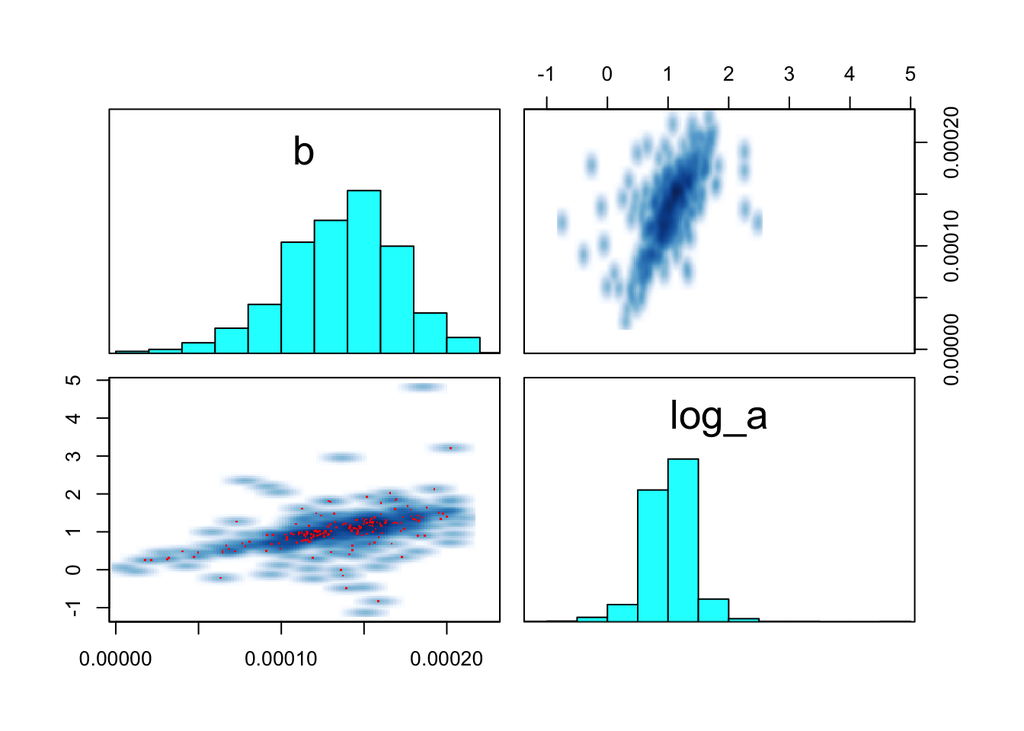

```r
# Rec <- extract(mod_fits[[1]], pars = "Rec", permuted = TRUE, inc_warmup = TRUE)$Rec
# R_tot <- unlist2(extract(mod_fits[[1]], pars = "R_tot", permuted = TRUE, inc_warmup = TRUE))
# pp <- extract(mod_fits[[1]], pars = "pp", permuted = TRUE, inc_warmup = TRUE)$Rec
#
# m1 <- as.array(mod_fits[[1]])
# #dev.new()
# par(mfrow=c(4,1), mai=c(0.6,0.6,0.1,0.1))
# apply(m1[,,"log_a"],2,acf)
#
# m2 <- as.matrix(mod_fits[[1]])
# #dev.new()
pairs(mod_fits[[1]], pars=c("b","log_a"))
```

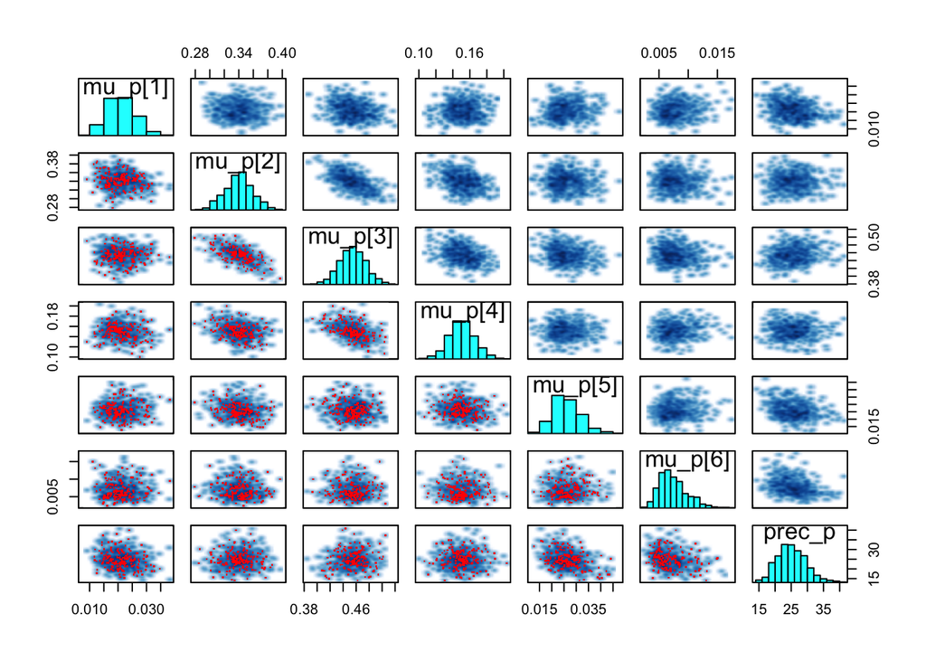

```r
pairs(mod_fits[[1]], pars=c("mu_p","prec_p"))
```

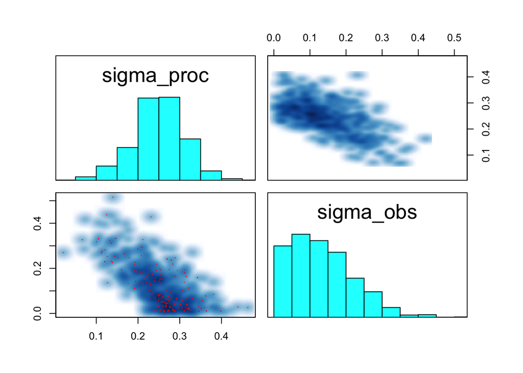

```r
pairs(mod_fits[[1]], pars=c("sigma_proc","sigma_obs"))
```

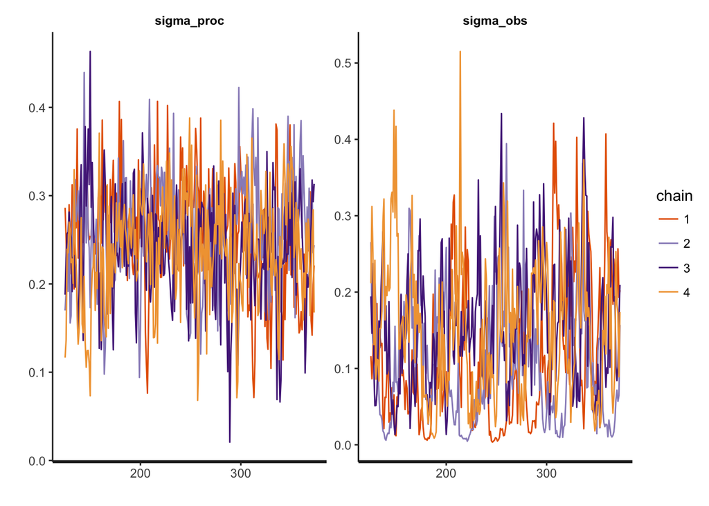

```r
traceplot(mod_fits[[1]], pars=c("sigma_proc","sigma_obs"))
```

```r
#traceplot(mod_fits[[1]], pars=colnames(m2)[grep("Rec",colnames(m2))])

get_posterior_mean(mod_fits[[1]], par=c("K","log_a","sigma_proc","sigma_obs"))
```

[output not shown]

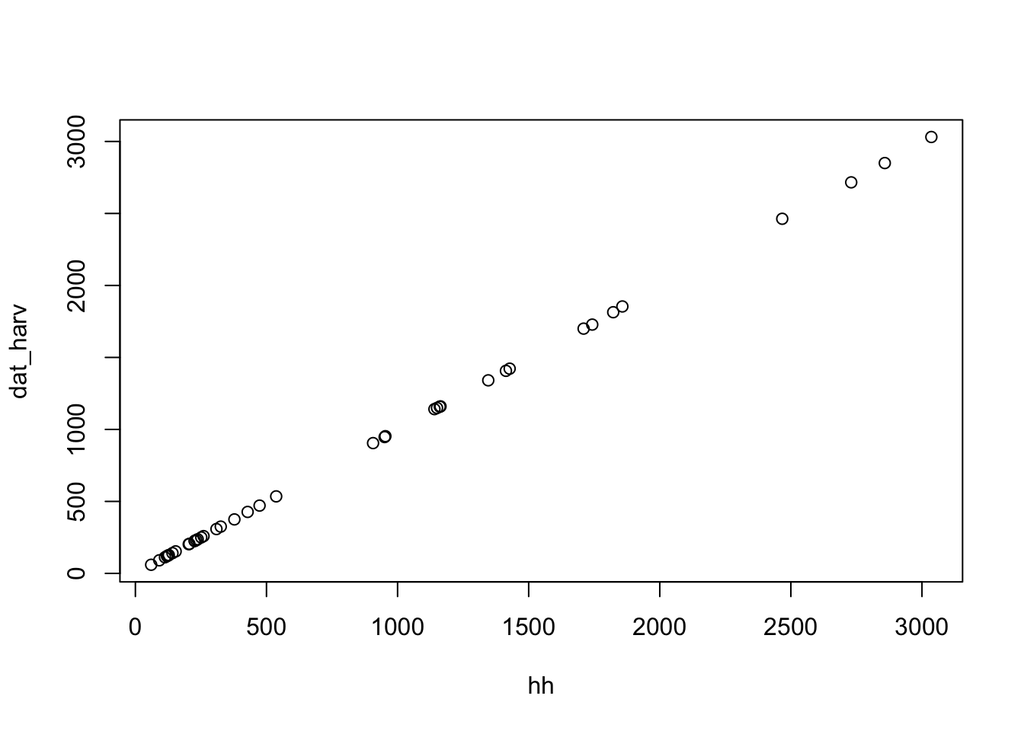

```r
mm <- as.matrix(mod_fits[[1]])
mm <- mm[,grep("harv",colnames(mm))]
hh <- apply(mm, 2, mean)
plot(hh, dat_harv)
```